# Project: Segmenting and Clustering Neighborhoods in Zürich, CH

[figure not shown]

This presentaion is part of the capstone project of the IBM Data Science Professional Certificate offer through Coursera. This submission contains all the tasks to be solved by means of Foursquare location data and Machine Learning Algorithms. All the required tasks to accomplish the project goals are part of this final report.  
The data for this project will be gathered from the web through a web scraping process using BeautifulSoup. Additional location data will be gathered from Foursquare using their API.

# This Presentation was created by: Gustavo Cedeño

# Introduction

> This presentaion is part of the capstone project of the IBM Data Science Professional Certificate offer through Coursera. This submission contains all the tasks to be solved by means of Foursquare location data and Machine Learning Algorithms. All the required tasks to accomplish the project goals are part of this final report.

# Zürich, Switzerland

> Zürich or Zurich (/ˈzjʊərɪk/ ZEWR-ik) is the largest city in Switzerland and the capital of the canton of Zürich. It is located in north-central Switzerland at the northwestern tip of Lake Zürich. The municipality has approximately 409,000 inhabitants. Zürich is a hub for railways, roads, and air traffic. Both Zurich Airport and railway station are the largest and busiest in the country.

> Zürich is a leading global city and among the world's largest financial centres despite having a relatively small population. The city is home to a large number of financial institutions and banking companies. Most of Switzerland's research and development centres are concentrated in Zürich and the low tax rates attract overseas companies to set up their headquarters there. Info taken from: [Zürich](https://en.wikipedia.org/wiki/Z%C3%BCrich)

## Problem Definition

> The main goal of this project is to provide business intelligence for an international company that is willing to open a new restaurant supply shop in Zürich. The target market for this kind of business is limited to those within the culinary community. This includes: restaurants, culinary schools, cafeterias(including medical and schools), bars, caterers, bakeries and coffee shops. Therefore, it is of major importance clustering places around the city and find out which ones of those concentrate venues which belong to the target market. This information will help decision makers choosing the right place for opening shops, planning logistics, calculating costs and designing better marketing campaigns.

## Project Details

> Main tasks in this project are as follows:
> 1. Gathering data
> 2. Assessing and cleaning data
> 3. Creating Visualizations
> 4. Using the Foursquare API to gather venues information.
> 5. Clustering.
> 6. Results analysis and giving recommedations.

## Data Source

> The whole data for this project is gathered from the web and from Foursquare location data service using their API. The idea is to create a dataset containing the different neighborhoods in the city of Zürich according to their respective postal codes, then add the geographical coordinates and venues information and location in each neighborhood. The final resulting dataset is used for creating clusters with different venues and find out which clusters constitute important segments to direct marketing campaigns.
> 1. **Zurich - postal codes** All the information regarding postal codes for the different neighborhoods in the city of Zürich will be gathered from the website [geonames_postalcodes_CH](https://www.geonames.org/postal-codes/CH/ZH/zurich.html) performing web scraping with the help of BeatifulSoup and then converting the data into a pandas DataFrame for further analysis.
> 2. **Additional Data via the Foursquare API** All the data related to venues will be gathered from Foursquare location data using their API. [Foursquare](https://foursquare.com/)

# Data Wrangling

> > Data wrangling, which consists of the following tasks:
> > 1. Gathering data
> > 2. Assessing data
> > 3. Cleaning data
> > 4. Storing, analyzing, and visualizing the wrangled data

## Gathering Data

### Scraping the web to obtain the postal codes data for the Neighborhoods in Zürich

> All the information regarding postal codes for the different neighborhoods in the city of Zürich will be gathered from the website [geonames_postalcodes_CH](https://www.geonames.org/postal-codes/CH/ZH/zurich.html) performing web scraping with the help of BeatifulSoup and then converting the data into a pandas DataFrame for further analysis.

## Transforming Data

### Transforming the data into a pandas dataframe

> The dataframe will consist of six columns: `Postalcode`,`Kanton`,`Borough`,`Place`,`Latitute` and `Longitude`

```python
#Finding the right table and getting the data from the HTML script
My_table = soup.find('table',{'class':'restable'})
fields = My_table.find_all('td')
#Getting the data into a python list
data_fields=[]
for field in fields:
    data_fields.append(field.text.strip())
#Extracting the required data
place=[]
postcode = []
Kanton = []
Bezirk = []
GeoCoords= []
for i in range(0, len(data_fields), 9):#every field has 9 elements
    if i <=1791: #last row with complete data
        place.append(data_fields[i+1])
        postcode.append(data_fields[i+2])
        Kanton.append(data_fields[i+4])
        Bezirk.append(data_fields[i+5])
        GeoCoords.append(data_fields[i+8])
#Creating the DataFrame using the data gethered from the web
df_Zurich = pd.DataFrame(data=[postcode,Kanton,Bezirk,place,GeoCoords]).transpose()
df_Zurich.columns = ['Postalcode', 'Kanton', 'Borough','Place','Location']
#Checking the resulted df
print(df_Zurich.shape)
df_Zurich.head()
```

```
(200, 5)
```

|  | Postalcode | Kanton | Borough | Place | Location |
| --- | --- | --- | --- | --- | --- |
| 0 | 8001 | Kanton Zürich | Bezirk Zürich | Zürich | 47.367/8.55 |
| 1 | 8002 | Kanton Zürich | Bezirk Zürich | Zürich | 47.367/8.55 |
| 2 | 8003 | Kanton Zürich | Bezirk Zürich | Zürich | 47.367/8.55 |
| 3 | 8004 | Kanton Zürich | Bezirk Zürich | Zürich | 47.367/8.55 |
| 4 | 8005 | Kanton Zürich | Bezirk Zürich | Zürich | 47.367/8.55 |

# Methodology

> In this project, I will apply unsupervised learning techniques to identify clusters of venues in the city of Zürich, Switzerland and then create city segments based on the venues belonging to each cluster. These segments can then be used by the investors to make better business decisions like for instance directing marketing campaigns towards audiences that will have the highest expected rate of returns. Since the main task consist in clustering, I will apply k-means clustering to the dataset and use the average within-cluster distances from each point to their assigned cluster's centroid to decide on a number of clusters to keep.

## Data Analysis and Clustering

> Before aplying machine learning algorithms it is necessary to gather the venues data using the Foursquare API, perform some exploratory data analysis and preprocess the data and get it ready for KMeans clustering.

## Creating some Visualizations

### Creating a map of Zurich with neighborhoods superimposed on top.

```python
# create map of Zurich using latitude and longitude values
map_Zurich = folium.Map(location=[latitude, longitude], zoom_start=10)

# add markers to map
for lat, lng, borough, neighborhood in zip(zurich_data['Latitude'], zurich_data['Longitude'], zurich_data['Borough'], zurich_data['Place']):
    label = '{}, {}'.format(neighborhood, borough)
    label = folium.Popup(label, parse_html=True)
    folium.CircleMarker(
        [lat, lng],
        radius=5,
        popup=label,
        color='blue',
        fill=True,
        fill_color='#3186cc',
        fill_opacity=0.7,
        parse_html=False).add_to(map_Zurich)

map_Zurich
```

[interactive chart not shown]

## Foursquare API

### Using the Foursquare API to explore the neighborhoods and segment them.

## Clustering

### Cluster Neighborhoods

> In this substep, I will apply k-means clustering to the pre-processed dataset and use the average within-cluster distances from each point to their assigned cluster's centroid to decide on a number of clusters to keep. To help choosing the right k for clustering, I use a function that gets the Sum Squared of Errors for each number of clusters and then plot the errors for different values o ks. The final k has to show a significant reduction in error and should not be too large in order to be used properly.

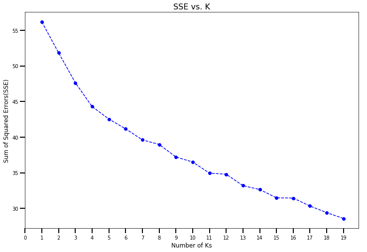

```python
scores = []
#testing for cluster counts through 20 clusters
ks=20
k_values = list(range(1,ks))

for k in k_values:
    scores.append(kmeans_score(zurich_grouped_clustering , k))

plt.figure(figsize=(12, 8))
ax = plt.subplot(111)
ax.plot(k_values, scores, linestyle='--', marker='o', color='b');
ax.xaxis.set_tick_params(width=2, length=10)
ax.yaxis.set_tick_params(width=2, length=10)
plt.xlabel('Number of Ks',fontsize=12)
plt.ylabel('Sum of Squared Errors(SSE)',fontsize=12)
plt.xticks(np.arange(0, ks, 1))
plt.title('SSE vs. K',fontsize=16)
plt.show()
```

## Selecting k

> Using the elbow method to determine the optimal number of clusters for k-means clustering, it can be noticed from the plot, that the errors (SSE) continue falling with increasing number of clusters. However, since the goal of clustering is to identify segments to be used for directing marketing campaigns towards audiences that will have the highest expeted rate of returns, creating a high number of clusters might not be so beneficial and doesn't make much sense if the marketing campaigns will only be directed to some specific clusters and the others might just be discarded, meaning that after some point each additional cluster provides even a smaller net benefit. Considering that, and based on the SSE vs. k curve besides the practical application of the created cluster, I would suggest a k = 9 to be a proper value that satisfies the two conditions of not being to large to make marketing results analysis and application too complex, and also showing a significant reduction in error (SSE).

# Results

> Finally, let's visualize the resulting clusters

```python
# create map
map_clusters = folium.Map(location=[latitude, longitude], zoom_start=11)

# set color scheme for the clusters
x = np.arange(kclusters)
ys = [i + x + (i*x)**2 for i in range(kclusters)]
colors_array = cm.rainbow(np.linspace(0, 1, len(ys)))
rainbow = [colors.rgb2hex(i) for i in colors_array]

# add markers to the map
markers_colors = []
for lat, lon, poi, cluster in zip(zurich_merged['Latitude'], zurich_merged['Longitude'], zurich_merged['Neighborhood'], zurich_merged['Cluster Labels']):
    label = folium.Popup(str(poi) + ' Cluster ' + str(cluster), parse_html=True)
    folium.CircleMarker(
        [lat, lon],
        radius=5,
        popup=label,
        color=rainbow[cluster-1],
        fill=True,
        fill_color=rainbow[cluster-1],
        fill_opacity=0.7).add_to(map_clusters)
    #print(cluster+1,color)

map_clusters
```

[interactive chart not shown]

## Examine Clusters

> Now,we can examine each cluster and determine the discriminating venue categories that distinguish each cluster. Based on the defining categories, we can then select the most interesting clusters.

# Cluster 1

```python
zurich_merged.loc[zurich_merged['Cluster Labels'] == 0, zurich_merged.columns[[1] + list(range(5, zurich_merged.shape[1]))]]
```

|  | Kanton | Longitude | Cluster Labels | 1st Most Common Venue | 2nd Most Common Venue | 3rd Most Common Venue | 4th Most Common Venue | 5th Most Common Venue | 6th Most Common Venue | 7th Most Common Venue | 8th Most Common Venue | 9th Most Common Venue | 10th Most Common Venue |
| --- | --- | --- | --- | --- | --- | --- | --- | --- | --- | --- | --- | --- | --- |
| 40 | Kanton Zürich | 8.691 | 0 | Gym | Hotel | Swiss Restaurant | Factory | Food & Drink Shop | Food | Flower Shop | Field | Fast Food Restaurant | Farmers Market |
| 50 | Kanton Zürich | 8.669 | 0 | Hotel | Supermarket | Swiss Restaurant | Restaurant | Food Court | Factory | Food | Flower Shop | Field | Fast Food Restaurant |
| 60 | Kanton Zürich | 8.391 | 0 | Brewery | Swiss Restaurant | Bakery | Grocery Store | Food Truck | Food Court | Food & Drink Shop | Food | Flower Shop | Field |
| 61 | Kanton Zürich | 8.627 | 0 | Sporting Goods Shop | Swiss Restaurant | Factory | Food & Drink Shop | Food | Flower Shop | Field | Fast Food Restaurant | Farmers Market | Farm |
| 68 | Kanton Zürich | 8.576 | 0 | Swiss Restaurant | Pool | Bus Station | Zoo Exhibit | Factory | Food | Flower Shop | Field | Fast Food Restaurant | Farmers Market |
| 73 | Kanton Zürich | 8.502 | 0 | Construction & Landscaping | Swiss Restaurant | Italian Restaurant | Bakery | Falafel Restaurant | Food & Drink Shop | Food | Flower Shop | Field | Fast Food Restaurant |
| 75 | Kanton Zürich | 8.554 | 0 | Swiss Restaurant | American Restaurant | Flower Shop | Gastropub | Zoo Exhibit | Falafel Restaurant | Food & Drink Shop | Food | Field | Fast Food Restaurant |
| 76 | Kanton Zürich | 8.502 | 0 | Swiss Restaurant | Market | Convenience Store | Gastropub | Bus Stop | Zoo Exhibit | Food | Flower Shop | Field | Fast Food Restaurant |
| 77 | Kanton Zürich | 8.521 | 0 | Café | Dessert Shop | Bistro | Swiss Restaurant | Beach | Farm | Food Court | Food & Drink Shop | Food | Flower Shop |
| 81 | Kanton Zürich | 8.633 | 0 | IT Services | Snack Place | Shopping Mall | Discount Store | Italian Restaurant | Swiss Restaurant | Bus Station | Bakery | Zoo Exhibit | Farmers Market |
| 83 | Kanton Zürich | 8.649 | 0 | Soccer Field | Swiss Restaurant | Miscellaneous Shop | Bakery | Zoo Exhibit | Farm | Food & Drink Shop | Food | Flower Shop | Field |
| 91 | Kanton Zürich | 8.665 | 0 | Convenience Store | Swiss Restaurant | Falafel Restaurant | Food Court | Food & Drink Shop | Food | Flower Shop | Field | Fast Food Restaurant | Farmers Market |
| 94 | Kanton Zürich | 8.594 | 0 | Shopping Mall | Food & Drink Shop | Swiss Restaurant | Bus Station | Falafel Restaurant | Food | Flower Shop | Field | Fast Food Restaurant | Farmers Market |
| 107 | Kanton Zürich | 8.689 | 0 | Swiss Restaurant | Train Station | Trail | Gym | Zoo Exhibit | Event Service | Food | Flower Shop | Field | Fast Food Restaurant |
| 108 | Kanton Zürich | 8.681 | 0 | Swiss Restaurant | Shopping Mall | Furniture / Home Store | Train Station | Palace | Gym | Zoo Exhibit | Factory | Field | Fast Food Restaurant |
| 110 | Kanton Zürich | 8.742 | 0 | Hotel | Zoo Exhibit | Factory | Food & Drink Shop | Food | Flower Shop | Field | Fast Food Restaurant | Farmers Market | Farm |
| 111 | Kanton Zürich | 8.720 | 0 | Motorcycle Shop | Swiss Restaurant | Shopping Mall | Farmers Market | Zoo Exhibit | Food Truck | Food & Drink Shop | Food | Flower Shop | Field |
| 112 | Kanton Zürich | 8.720 | 0 | Swiss Restaurant | Italian Restaurant | Bus Station | Event Service | Zoo Exhibit | Falafel Restaurant | Food & Drink Shop | Food | Flower Shop | Field |
| 119 | Kanton Zürich | 8.584 | 0 | Hotel | Swiss Restaurant | Bakery | Paper / Office Supplies Store | Grocery Store | Gym | Pharmacy | Train Station | Italian Restaurant | Supermarket |
| 122 | Kanton Zürich | 8.679 | 0 | Convenience Store | Supermarket | Swiss Restaurant | Italian Restaurant | Zoo Exhibit | Falafel Restaurant | Food & Drink Shop | Food | Flower Shop | Field |
| 134 | Kanton Zürich | 8.463 | 0 | Swiss Restaurant | Recycling Facility | Restaurant | Train Station | Electronics Store | Zoo Exhibit | Event Service | Flower Shop | Field | Fast Food Restaurant |
| 137 | Kanton Zürich | 8.600 | 0 | Yoga Studio | Plaza | Swiss Restaurant | Restaurant | Zoo Exhibit | Factory | Food | Flower Shop | Field | Fast Food Restaurant |
| 139 | Kanton Zürich | 8.437 | 0 | Supermarket | Swiss Restaurant | Food | Miscellaneous Shop | Zoo Exhibit | Food Truck | Food & Drink Shop | Flower Shop | Field | Fast Food Restaurant |
| 147 | Kanton Zürich | 8.548 | 0 | Supermarket | Swiss Restaurant | Flower Shop | Bakery | Light Rail Station | Zoo Exhibit | Falafel Restaurant | Food & Drink Shop | Food | Field |
| 148 | Kanton Zürich | 8.457 | 0 | Café | Swiss Restaurant | Beer Garden | Bakery | Farm | Food Court | Food & Drink Shop | Food | Flower Shop | Field |
| 149 | Kanton Zürich | 8.487 | 0 | Trail | Swiss Restaurant | Outdoor Sculpture | Scenic Lookout | Hotel | Light Rail Station | Mountain | Hotel Bar | Discount Store | Farm |
| 151 | Kanton Zürich | 8.499 | 0 | Swiss Restaurant | Flower Shop | Bus Station | Zoo Exhibit | Falafel Restaurant | Food & Drink Shop | Food | Field | Fast Food Restaurant | Farmers Market |
| 162 | Kanton Zürich | 8.704 | 0 | Gas Station | Swiss Restaurant | Rest Area | Café | Zoo Exhibit | Factory | Food | Flower Shop | Field | Fast Food Restaurant |
| 193 | Kanton Zürich | 8.443 | 0 | Wine Shop | Food & Drink Shop | Diner | Pizza Place | Swiss Restaurant | Bakery | Bus Station | Zoo Exhibit | Farm | Food |
| 195 | Kanton Zürich | 8.497 | 0 | Café | Swiss Restaurant | Factory | Food & Drink Shop | Food | Flower Shop | Field | Fast Food Restaurant | Farmers Market | Farm |
| 199 | Kanton Zürich | 8.527 | 0 | Swiss Restaurant | Discount Store | Zoo Exhibit | Falafel Restaurant | Food Court | Food & Drink Shop | Food | Flower Shop | Field | Fast Food Restaurant |

# Cluster 2

```python
zurich_merged.loc[zurich_merged['Cluster Labels'] == 1, zurich_merged.columns[[1] + list(range(5, zurich_merged.shape[1]))]]
```

|  | Kanton | Longitude | Cluster Labels | 1st Most Common Venue | 2nd Most Common Venue | 3rd Most Common Venue | 4th Most Common Venue | 5th Most Common Venue | 6th Most Common Venue | 7th Most Common Venue | 8th Most Common Venue | 9th Most Common Venue | 10th Most Common Venue |
| --- | --- | --- | --- | --- | --- | --- | --- | --- | --- | --- | --- | --- | --- |
| 138 | Kanton Zürich | 8.436 | 1 | Restaurant | Swiss Restaurant | Zoo Exhibit | Event Service | Food | Flower Shop | Field | Fast Food Restaurant | Farmers Market | Farm |
| 165 | Kanton Zürich | 8.807 | 1 | Restaurant | Zoo Exhibit | Factory | Food & Drink Shop | Food | Flower Shop | Field | Fast Food Restaurant | Farmers Market | Farm |
| 166 | Kanton Zürich | 8.775 | 1 | Restaurant | Zoo Exhibit | Factory | Food & Drink Shop | Food | Flower Shop | Field | Fast Food Restaurant | Farmers Market | Farm |
| 171 | Kanton Zürich | 8.594 | 1 | Restaurant | Shopping Mall | Business Service | Zoo Exhibit | Factory | Food | Flower Shop | Field | Fast Food Restaurant | Farmers Market |
| 176 | Kanton Zürich | 8.654 | 1 | Restaurant | Zoo Exhibit | Factory | Food & Drink Shop | Food | Flower Shop | Field | Fast Food Restaurant | Farmers Market | Farm |
| 177 | Kanton Zürich | 8.689 | 1 | Swiss Restaurant | Restaurant | Zoo Exhibit | Event Service | Food | Flower Shop | Field | Fast Food Restaurant | Farmers Market | Farm |
| 180 | Kanton Zürich | 8.728 | 1 | Restaurant | Train Station | Zoo Exhibit | Event Service | Food | Flower Shop | Field | Fast Food Restaurant | Farmers Market | Farm |
| 187 | Kanton Zürich | 8.718 | 1 | Restaurant | Brewery | Bus Station | Zoo Exhibit | Falafel Restaurant | Food & Drink Shop | Food | Flower Shop | Field | Fast Food Restaurant |
| 192 | Kanton Zürich | 8.667 | 1 | Swiss Restaurant | Restaurant | Zoo Exhibit | Event Service | Food | Flower Shop | Field | Fast Food Restaurant | Farmers Market | Farm |
| 194 | Kanton Zürich | 8.431 | 1 | Tunnel | Restaurant | Zoo Exhibit | Event Service | Food | Flower Shop | Field | Fast Food Restaurant | Farmers Market | Farm |

# Cluster 3

```python
zurich_merged.loc[zurich_merged['Cluster Labels'] == 2, zurich_merged.columns[[1] + list(range(5, zurich_merged.shape[1]))]]
```

|  | Kanton | Longitude | Cluster Labels | 1st Most Common Venue | 2nd Most Common Venue | 3rd Most Common Venue | 4th Most Common Venue | 5th Most Common Venue | 6th Most Common Venue | 7th Most Common Venue | 8th Most Common Venue | 9th Most Common Venue | 10th Most Common Venue |
| --- | --- | --- | --- | --- | --- | --- | --- | --- | --- | --- | --- | --- | --- |
| 71 | Kanton Zürich | 8.452 | 2 | Swiss Restaurant | Zoo Exhibit | Falafel Restaurant | Food Court | Food & Drink Shop | Food | Flower Shop | Field | Fast Food Restaurant | Farmers Market |
| 152 | Kanton Zürich | 8.439 | 2 | Swiss Restaurant | Zoo Exhibit | Falafel Restaurant | Food Court | Food & Drink Shop | Food | Flower Shop | Field | Fast Food Restaurant | Farmers Market |
| 160 | Kanton Zürich | 8.508 | 2 | Swiss Restaurant | Zoo Exhibit | Falafel Restaurant | Food Court | Food & Drink Shop | Food | Flower Shop | Field | Fast Food Restaurant | Farmers Market |

# Cluster 4

```python
zurich_merged.loc[zurich_merged['Cluster Labels'] == 3, zurich_merged.columns[[1] + list(range(5, zurich_merged.shape[1]))]]
```

|  | Kanton | Longitude | Cluster Labels | 1st Most Common Venue | 2nd Most Common Venue | 3rd Most Common Venue | 4th Most Common Venue | 5th Most Common Venue | 6th Most Common Venue | 7th Most Common Venue | 8th Most Common Venue | 9th Most Common Venue | 10th Most Common Venue |
| --- | --- | --- | --- | --- | --- | --- | --- | --- | --- | --- | --- | --- | --- |
| 24 | Kanton Zürich | 8.530 | 3 | Pizza Place | Airport Terminal | Convenience Store | Swiss Restaurant | Train Station | Zoo Exhibit | Factory | Food | Flower Shop | Field |
| 31 | Kanton Zürich | 8.751 | 3 | Convenience Store | Food & Drink Shop | Art Gallery | Train Station | Bakery | Falafel Restaurant | Food Court | Food | Flower Shop | Field |
| 39 | Kanton Zürich | 8.657 | 3 | Train Station | Café | Italian Restaurant | Zoo Exhibit | Food & Drink Shop | Food | Flower Shop | Field | Fast Food Restaurant | Farmers Market |
| 48 | Kanton Zürich | 8.697 | 3 | Print Shop | Grocery Store | Bus Stop | Train Station | Cheese Shop | Food | Flower Shop | Field | Fast Food Restaurant | Farmers Market |
| 72 | Kanton Zürich | 8.377 | 3 | Soccer Field | Swiss Restaurant | Train Station | Café | Zoo Exhibit | Factory | Food | Flower Shop | Field | Fast Food Restaurant |
| 78 | Kanton Zürich | 8.543 | 3 | Flower Shop | Miscellaneous Shop | Restaurant | Train Station | Zoo Exhibit | Factory | Food & Drink Shop | Food | Field | Fast Food Restaurant |
| 79 | Kanton Zürich | 8.644 | 3 | River | Hardware Store | Train Station | Pier | Zoo Exhibit | Event Service | Food | Flower Shop | Field | Fast Food Restaurant |
| 80 | Kanton Zürich | 8.630 | 3 | Cosmetics Shop | Train Station | Food & Drink Shop | Food Truck | Dessert Shop | Farm | Food Court | Deli / Bodega | Food | Flower Shop |
| 82 | Kanton Zürich | 8.721 | 3 | Grocery Store | Playground | Pizza Place | Swiss Restaurant | Train Station | Café | Event Service | Flower Shop | Field | Fast Food Restaurant |
| 88 | Kanton Zürich | 8.856 | 3 | Café | Theater | Factory | Food & Drink Shop | Food | Flower Shop | Field | Fast Food Restaurant | Farmers Market | Farm |
| 89 | Kanton Zürich | 8.865 | 3 | Print Shop | Convenience Store | Furniture / Home Store | Train Station | Factory | Food | Flower Shop | Field | Fast Food Restaurant | Farmers Market |
| 93 | Kanton Zürich | 8.642 | 3 | Café | Gastropub | Train Station | Factory | Food & Drink Shop | Food | Flower Shop | Field | Fast Food Restaurant | Farmers Market |
| 97 | Kanton Zürich | 8.618 | 3 | Café | Grocery Store | Beach | Miscellaneous Shop | Train Station | Food & Drink Shop | Food | Flower Shop | Field | Fast Food Restaurant |
| 101 | Kanton Zürich | 8.732 | 3 | Grocery Store | Convenience Store | Italian Restaurant | Train Station | Zoo Exhibit | Factory | Food | Flower Shop | Field | Fast Food Restaurant |
| 103 | Kanton Zürich | 8.846 | 3 | Construction & Landscaping | Train Station | Electronics Store | Hotel | Deli / Bodega | Falafel Restaurant | Food & Drink Shop | Food | Flower Shop | Field |
| 104 | Kanton Zürich | 8.845 | 3 | Construction & Landscaping | Train Station | Café | Thrift / Vintage Store | Department Store | Dessert Shop | Food | Flower Shop | Field | Fast Food Restaurant |
| 120 | Kanton Zürich | 8.574 | 3 | Grocery Store | Yoga Studio | Convenience Store | Field | Swiss Restaurant | Beach | Train Station | Zoo Exhibit | Food | Flower Shop |
| 124 | Kanton Zürich | 8.545 | 3 | Supermarket | Gastropub | Train Station | Café | Zoo Exhibit | Factory | Food | Flower Shop | Field | Fast Food Restaurant |
| 127 | Kanton Zürich | 8.682 | 3 | Food & Drink Shop | Bus Stop | Train Station | Zoo Exhibit | Factory | Food | Flower Shop | Field | Fast Food Restaurant | Farmers Market |
| 130 | Kanton Zürich | 8.448 | 3 | Construction & Landscaping | Bakery | Train Station | Falafel Restaurant | Food Court | Food & Drink Shop | Food | Flower Shop | Field | Fast Food Restaurant |
| 153 | Kanton Zürich | 8.418 | 3 | Brewery | Swiss Restaurant | Train Station | Zoo Exhibit | Falafel Restaurant | Food & Drink Shop | Food | Flower Shop | Field | Fast Food Restaurant |
| 154 | Kanton Zürich | 8.407 | 3 | Train Station | Zoo Exhibit | Factory | Food Court | Food & Drink Shop | Food | Flower Shop | Field | Fast Food Restaurant | Farmers Market |
| 172 | Kanton Zürich | 8.682 | 3 | Home Service | Train Station | Hardware Store | Zoo Exhibit | Factory | Food & Drink Shop | Food | Flower Shop | Field | Fast Food Restaurant |
| 175 | Kanton Zürich | 8.648 | 3 | Concert Hall | Train Station | Bus Stop | Zoo Exhibit | Falafel Restaurant | Food & Drink Shop | Food | Flower Shop | Field | Fast Food Restaurant |
| 182 | Kanton Zürich | 8.822 | 3 | Playground | Train Station | Zoo Exhibit | Factory | Food & Drink Shop | Food | Flower Shop | Field | Fast Food Restaurant | Farmers Market |
| 183 | Kanton Zürich | 8.853 | 3 | Cheese Shop | Event Service | Restaurant | Train Station | Food | Flower Shop | Field | Fast Food Restaurant | Farmers Market | Farm |

# Cluster 5

```python
zurich_merged.loc[zurich_merged['Cluster Labels'] == 4, zurich_merged.columns[[1] + list(range(5, zurich_merged.shape[1]))]]
```

|  | Kanton | Longitude | Cluster Labels | 1st Most Common Venue | 2nd Most Common Venue | 3rd Most Common Venue | 4th Most Common Venue | 5th Most Common Venue | 6th Most Common Venue | 7th Most Common Venue | 8th Most Common Venue | 9th Most Common Venue | 10th Most Common Venue |
| --- | --- | --- | --- | --- | --- | --- | --- | --- | --- | --- | --- | --- | --- |
| 135 | Kanton Zürich | 8.427 | 4 | Bus Station | Zoo Exhibit | Food Truck | Food & Drink Shop | Food | Flower Shop | Field | Fast Food Restaurant | Farmers Market | Farm |
| 143 | Kanton Zürich | 8.637 | 4 | Bus Station | Grocery Store | Zoo Exhibit | Falafel Restaurant | Food & Drink Shop | Food | Flower Shop | Field | Fast Food Restaurant | Farmers Market |
| 158 | Kanton Zürich | 8.433 | 4 | Bus Station | Zoo Exhibit | Food Truck | Food & Drink Shop | Food | Flower Shop | Field | Fast Food Restaurant | Farmers Market | Farm |
| 161 | Kanton Zürich | 8.635 | 4 | Bus Station | Zoo Exhibit | Food Truck | Food & Drink Shop | Food | Flower Shop | Field | Fast Food Restaurant | Farmers Market | Farm |
| 190 | Kanton Zürich | 8.783 | 4 | Bus Station | Zoo Exhibit | Food Truck | Food & Drink Shop | Food | Flower Shop | Field | Fast Food Restaurant | Farmers Market | Farm |
| 197 | Kanton Zürich | 8.533 | 4 | Bus Station | Grocery Store | Zoo Exhibit | Falafel Restaurant | Food & Drink Shop | Food | Flower Shop | Field | Fast Food Restaurant | Farmers Market |

# Cluster 6

```python
zurich_merged.loc[zurich_merged['Cluster Labels'] == 5, zurich_merged.columns[[1] + list(range(5, zurich_merged.shape[1]))]]
```

|  | Kanton | Longitude | Cluster Labels | 1st Most Common Venue | 2nd Most Common Venue | 3rd Most Common Venue | 4th Most Common Venue | 5th Most Common Venue | 6th Most Common Venue | 7th Most Common Venue | 8th Most Common Venue | 9th Most Common Venue | 10th Most Common Venue |
| --- | --- | --- | --- | --- | --- | --- | --- | --- | --- | --- | --- | --- | --- |
| 63 | Kanton Zürich | 8.668 | 5 | Italian Restaurant | Restaurant | Zoo Exhibit | Factory | Food & Drink Shop | Food | Flower Shop | Field | Fast Food Restaurant | Farmers Market |
| 150 | Kanton Zürich | 8.490 | 5 | Italian Restaurant | Zoo Exhibit | Factory | Food Court | Food & Drink Shop | Food | Flower Shop | Field | Fast Food Restaurant | Farmers Market |
| 168 | Kanton Zürich | 8.840 | 5 | Italian Restaurant | Zoo Exhibit | Factory | Food Court | Food & Drink Shop | Food | Flower Shop | Field | Fast Food Restaurant | Farmers Market |

# Cluster 7

```python
zurich_merged.loc[zurich_merged['Cluster Labels'] == 6, zurich_merged.columns[[1] + list(range(5, zurich_merged.shape[1]))]]
```

|  | Kanton | Longitude | Cluster Labels | 1st Most Common Venue | 2nd Most Common Venue | 3rd Most Common Venue | 4th Most Common Venue | 5th Most Common Venue | 6th Most Common Venue | 7th Most Common Venue | 8th Most Common Venue | 9th Most Common Venue | 10th Most Common Venue |
| --- | --- | --- | --- | --- | --- | --- | --- | --- | --- | --- | --- | --- | --- |
| 115 | Kanton Zürich | 8.856 | 6 | Gym / Fitness Center | Hardware Store | Convenience Store | Department Store | Dessert Shop | Food & Drink Shop | Food | Flower Shop | Field | Fast Food Restaurant |
| 167 | Kanton Zürich | 8.865 | 6 | Gym / Fitness Center | Food Truck | Food & Drink Shop | Food | Flower Shop | Field | Fast Food Restaurant | Farmers Market | Farm | Falafel Restaurant |

# Cluster 8

```python
zurich_merged.loc[zurich_merged['Cluster Labels'] == 7, zurich_merged.columns[[1] + list(range(5, zurich_merged.shape[1]))]]
```

|  | Kanton | Longitude | Cluster Labels | 1st Most Common Venue | 2nd Most Common Venue | 3rd Most Common Venue | 4th Most Common Venue | 5th Most Common Venue | 6th Most Common Venue | 7th Most Common Venue | 8th Most Common Venue | 9th Most Common Venue | 10th Most Common Venue |
| --- | --- | --- | --- | --- | --- | --- | --- | --- | --- | --- | --- | --- | --- |
| 114 | Kanton Zürich | 8.75 | 7 | Mountain | Garden Center | Zoo Exhibit | Falafel Restaurant | Food & Drink Shop | Food | Flower Shop | Field | Fast Food Restaurant | Farmers Market |
| 196 | Kanton Zürich | 8.49 | 7 | Mountain | Zoo Exhibit | Falafel Restaurant | Food Court | Food & Drink Shop | Food | Flower Shop | Field | Fast Food Restaurant | Farmers Market |

# Cluster 9

```python
zurich_merged.loc[zurich_merged['Cluster Labels'] == 8, zurich_merged.columns[[1] + list(range(5, zurich_merged.shape[1]))]]
```

|  | Kanton | Longitude | Cluster Labels | 1st Most Common Venue | 2nd Most Common Venue | 3rd Most Common Venue | 4th Most Common Venue | 5th Most Common Venue | 6th Most Common Venue | 7th Most Common Venue | 8th Most Common Venue | 9th Most Common Venue | 10th Most Common Venue |
| --- | --- | --- | --- | --- | --- | --- | --- | --- | --- | --- | --- | --- | --- |
| 0 | Kanton Zürich | 8.550 | 8 | Hotel | Italian Restaurant | Café | Swiss Restaurant | Bar | Plaza | Coffee Shop | Lounge | Supermarket | Opera House |
| 1 | Kanton Zürich | 8.550 | 8 | Hotel | Italian Restaurant | Café | Swiss Restaurant | Bar | Plaza | Coffee Shop | Lounge | Supermarket | Opera House |
| 2 | Kanton Zürich | 8.550 | 8 | Hotel | Italian Restaurant | Café | Swiss Restaurant | Bar | Plaza | Coffee Shop | Lounge | Supermarket | Opera House |
| 3 | Kanton Zürich | 8.550 | 8 | Hotel | Italian Restaurant | Café | Swiss Restaurant | Bar | Plaza | Coffee Shop | Lounge | Supermarket | Opera House |
| 4 | Kanton Zürich | 8.550 | 8 | Hotel | Italian Restaurant | Café | Swiss Restaurant | Bar | Plaza | Coffee Shop | Lounge | Supermarket | Opera House |
| 5 | Kanton Zürich | 8.550 | 8 | Hotel | Italian Restaurant | Café | Swiss Restaurant | Bar | Plaza | Coffee Shop | Lounge | Supermarket | Opera House |
| 6 | Kanton Zürich | 8.550 | 8 | Hotel | Italian Restaurant | Café | Swiss Restaurant | Bar | Plaza | Coffee Shop | Lounge | Supermarket | Opera House |
| 7 | Kanton Zürich | 8.550 | 8 | Hotel | Italian Restaurant | Café | Swiss Restaurant | Bar | Plaza | Coffee Shop | Lounge | Supermarket | Opera House |
| 8 | Kanton Zürich | 8.550 | 8 | Hotel | Italian Restaurant | Café | Swiss Restaurant | Bar | Plaza | Coffee Shop | Lounge | Supermarket | Opera House |
| 9 | Kanton Zürich | 8.550 | 8 | Hotel | Italian Restaurant | Café | Swiss Restaurant | Bar | Plaza | Coffee Shop | Lounge | Supermarket | Opera House |
| 10 | Kanton Zürich | 8.550 | 8 | Hotel | Italian Restaurant | Café | Swiss Restaurant | Bar | Plaza | Coffee Shop | Lounge | Supermarket | Opera House |
| 11 | Kanton Zürich | 8.550 | 8 | Hotel | Italian Restaurant | Café | Swiss Restaurant | Bar | Plaza | Coffee Shop | Lounge | Supermarket | Opera House |
| 12 | Kanton Zürich | 8.550 | 8 | Hotel | Italian Restaurant | Café | Swiss Restaurant | Bar | Plaza | Coffee Shop | Lounge | Supermarket | Opera House |
| 13 | Kanton Zürich | 8.550 | 8 | Hotel | Italian Restaurant | Café | Swiss Restaurant | Bar | Plaza | Coffee Shop | Lounge | Supermarket | Opera House |
| 14 | Kanton Zürich | 8.550 | 8 | Hotel | Italian Restaurant | Café | Swiss Restaurant | Bar | Plaza | Coffee Shop | Lounge | Supermarket | Opera House |
| 15 | Kanton Zürich | 8.550 | 8 | Hotel | Italian Restaurant | Café | Swiss Restaurant | Bar | Plaza | Coffee Shop | Lounge | Supermarket | Opera House |
| 16 | Kanton Zürich | 8.550 | 8 | Hotel | Italian Restaurant | Café | Swiss Restaurant | Bar | Plaza | Coffee Shop | Lounge | Supermarket | Opera House |
| 17 | Kanton Zürich | 8.550 | 8 | Hotel | Italian Restaurant | Café | Swiss Restaurant | Bar | Plaza | Coffee Shop | Lounge | Supermarket | Opera House |
| 18 | Kanton Zürich | 8.550 | 8 | Hotel | Italian Restaurant | Café | Swiss Restaurant | Bar | Plaza | Coffee Shop | Lounge | Supermarket | Opera House |
| 19 | Kanton Zürich | 8.550 | 8 | Hotel | Italian Restaurant | Café | Swiss Restaurant | Bar | Plaza | Coffee Shop | Lounge | Supermarket | Opera House |
| 20 | Kanton Zürich | 8.550 | 8 | Hotel | Italian Restaurant | Café | Swiss Restaurant | Bar | Plaza | Coffee Shop | Lounge | Supermarket | Opera House |
| 21 | Kanton Zürich | 8.469 | 8 | Sporting Goods Shop | Restaurant | Supermarket | Gym / Fitness Center | Pizza Place | Shopping Mall | Bookstore | Gas Station | Thai Restaurant | Hotel |
| 22 | Kanton Zürich | 8.525 | 8 | Supermarket | Light Rail Station | Snack Place | Fast Food Restaurant | Arts & Crafts Store | Bus Station | Restaurant | Falafel Restaurant | Factory | Flower Shop |
| 23 | Kanton Zürich | 8.563 | 8 | Italian Restaurant | Chinese Restaurant | Hotel | Supermarket | Thai Restaurant | Train Station | Japanese Restaurant | Gas Station | Kebab Restaurant | Café |
| 25 | Kanton Zürich | 8.540 | 8 | Italian Restaurant | Bakery | Pub | Lounge | Shopping Mall | Grocery Store | Gym / Fitness Center | Train Station | Mobile Phone Shop | Indie Movie Theater |
| 26 | Kanton Zürich | 8.585 | 8 | Hotel | Italian Restaurant | Swiss Restaurant | Pizza Place | Asian Restaurant | Bus Station | Steakhouse | Supermarket | Bakery | Department Store |
| 27 | Kanton Zürich | 8.629 | 8 | Shopping Mall | Pizza Place | Art Gallery | Convenience Store | Steakhouse | Supermarket | Italian Restaurant | Swiss Restaurant | Lake | Falafel Restaurant |
| 28 | Kanton Zürich | 8.597 | 8 | Platform | Supermarket | Food & Drink Shop | Shopping Mall | Wine Bar | Pool | Train Station | Italian Restaurant | Bakery | Factory |
| 29 | Kanton Zürich | 8.619 | 8 | Bus Station | Train Station | Men's Store | Café | Food & Drink Shop | Grocery Store | Gas Station | Electronics Store | Bakery | Supermarket |
| 30 | Kanton Zürich | 8.691 | 8 | Supermarket | Platform | Department Store | Shopping Mall | Restaurant | Train Station | Zoo Exhibit | Factory | Flower Shop | Field |

[output cut: 77 more lines]

# References

- [Geo_Data_Switzerland](http://www.ralphstraumann.ch/blog/2011/10/zipscribble-map-switzerland-part-i/)
- [geonames_postalcodes_CH](https://www.geonames.org/postal-codes/CH/ZH/zurich.html)
- [BeautifulSoup Documentation](https://www.crummy.com/software/BeautifulSoup/bs4/doc/)
- [Web Scraping Wikipedia Tables using BeautifulSoup and Python](https://medium.com/analytics-vidhya/web-scraping-wiki-tables-using-beautifulsoup-and-python-6b9ea26d8722)
- [Foursquare](https://foursquare.com/)
- [Python Data Science Handbook](https://jakevdp.github.io/PythonDataScienceHandbook/)
- [IBM_Coursera_Data Science Certificate](https://www.coursera.org/specializations/ibm-data-science-professional-certificate)